# STAT 184 Final Project

EDA

Jonathan Sguera

## Guiding Question:

Do English Premier League matches have higher Full Time Total goals on average than Italian Serie A matches?

```r
# clean up workspace environment
rm(list = ls())

# all packages used for the assignment
library(mosaic)
library(tidyverse)
library(DataComputing)
```

## Acquainted with Data sources:

```r
# Here I am reading in the data from the website link I found it at
Serie_A_Data <- read.csv("https://datahub.io/sports-data/italian-serie-a/r/season-1819.csv")
Premier_League_Data <- read.csv("https://datahub.io/sports-data/english-premier-league/r/season-1819.csv")
```

### Where did you find them?

I found these data tables from datahub.io and I only included data from the 2018-19 season.

### Who collected/maintains them?

Key to results data:

Div = League Division Date = Match Date (dd/mm/yy) HomeTeam = Home Team AwayTeam = Away Team FTHG = Full Time Home Team Goals FTAG = Full Time Away Team Goals FTR = Full Time Result (H=Home Win, D=Draw, A=Away Win) HTHG = Half Time Home Team Goals HTAG = Half Time Away Team Goals HTR = Half Time Result (H=Home Win, D=Draw, A=Away Win)

Match Statistics (where available) Attendance = Crowd Attendance Referee = Match Referee HS = Home Team Shots AS = Away Team Shots HST = Home Team Shots on Target AST = Away Team Shots on Target HHW = Home Team Hit Woodwork AHW = Away Team Hit Woodwork HC = Home Team Corners AC = Away Team Corners HF = Home Team Fouls Committed AF = Away Team Fouls Committed HO = Home Team Offsides AO = Away Team Offsides HY = Home Team Yellow Cards AY = Away Team Yellow Cards HR = Home Team Red Cards AR = Away Team Red Cards HBP = Home Team Bookings Points (10 = yellow, 25 = red) ABP = Away Team Bookings Points (10 = yellow, 25 = red)

Key to 1X2 (match) betting odds data:

B365H = Bet365 home win odds B365D = Bet365 draw odds B365A = Bet365 away win odds BSH = Blue Square home win odds BSD = Blue Square draw odds BSA = Blue Square away win odds BWH = Bet&Win home win odds BWD = Bet&Win draw odds BWA = Bet&Win away win odds GBH = Gamebookers home win odds GBD = Gamebookers draw odds GBA = Gamebookers away win odds IWH = Interwetten home win odds IWD = Interwetten draw odds IWA = Interwetten away win odds LBH = Ladbrokes home win odds LBD = Ladbrokes draw odds LBA = Ladbrokes away win odds PSH = Pinnacle Sports home win odds PSD = Pinnacle Sports draw odds PSA = Pinnacle Sports away win odds SOH = Sporting Odds home win odds SOD = Sporting Odds draw odds SOA = Sporting Odds away win odds SBH = Sportingbet home win odds SBD = Sportingbet draw odds SBA = Sportingbet away win odds SJH = Stan James home win odds SJD = Stan James draw odds SJA = Stan James away win odds SYH = Stanleybet home win odds SYD = Stanleybet draw odds SYA = Stanleybet away win odds VCH = VC Bet home win odds VCD = VC Bet draw odds VCA = VC Bet away win odds WHH = William Hill home win odds WHD = William Hill draw odds WHA = William Hill away win odds

Bb1X2 = Number of BetBrain bookmakers used to calculate match odds averages and maximums BbMxH = Betbrain maximum home win odds BbAvH = Betbrain average home win odds BbMxD = Betbrain maximum draw odds BbAvD = Betbrain average draw win odds BbMxA = Betbrain maximum away win odds BbAvA = Betbrain average away win odds

Key to total goals betting odds:

BbOU = Number of BetBrain bookmakers used to calculate over/under 2.5 goals (total goals) averages and maximums BbMx>2.5 = Betbrain maximum over 2.5 goals BbAv>2.5 = Betbrain average over 2.5 goals BbMx<2.5 = Betbrain maximum under 2.5 goals BbAv<2.5 = Betbrain average under 2.5 goals

GB>2.5 = Gamebookers over 2.5 goals GB<2.5 = Gamebookers under 2.5 goals B365>2.5 = Bet365 over 2.5 goals B365<2.5 = Bet365 under 2.5 goals

Key to Asian handicap betting odds:

BbAH = Number of BetBrain bookmakers used to Asian handicap averages and maximums BbAHh = Betbrain size of handicap (home team) BbMxAHH = Betbrain maximum Asian handicap home team odds BbAvAHH = Betbrain average Asian handicap home team odds BbMxAHA = Betbrain maximum Asian handicap away team odds BbAvAHA = Betbrain average Asian handicap away team odds

GBAHH = Gamebookers Asian handicap home team odds GBAHA = Gamebookers Asian handicap away team odds GBAH = Gamebookers size of handicap (home team) LBAHH = Ladbrokes Asian handicap home team odds LBAHA = Ladbrokes Asian handicap away team odds LBAH = Ladbrokes size of handicap (home team) B365AHH = Bet365 Asian handicap home team odds B365AHA = Bet365 Asian handicap away team odds B365AH = Bet365 size of handicap (home team)

Football-Data would like to acknowledge the following sources which have been utilised in the compilation of Football-Data’s results and odds files.

Historical results: International Soccer Server - http://sunsite.tut.fi/rec/riku/soccer.html European Football - http://www.eurofootball.be/ RSSSF Archive - http://www.rsssf.com/

Current results (full time, half time) TBWSport - http://www.tbwsport.com Livescore- http://www.livescore.com

Match statistics Sportinglife, ESPN Soccer, Bundesliga.de, Gazzetta.it and Football.fr

Bookmakers betting odds Betbrain - http://www.betbrain.com Betbase - http://www.betbase.info

Betting odds for weekend games are collected Friday afternoons, and on Tuesday afternoons for midweek games.

Additional match statistics (corners, shots, bookings, referee etc.) for the 2000/01 and 2001/02 seasons for the English, Scottish and German leagues were provided by Sports.com (now under new ownership and no longer available).

### What does a case represent in each data source, and how many total cases are available?

A case represents one match played and there are 380 total cases in each dataset.

### What are some of the variables that you plan to use?

```r
SerieAClean <- Serie_A_Data %>%
  select(Date,HomeTeam,AwayTeam,FTHG,FTAG,FTR,HTHG,HTAG,HTR,HS,AS,HST,AST,HF,AF,HC,AC,HY,AY,HR,AR) %>%
  mutate(FTTG = FTAG + FTHG,
         HTTG = HTAG + HTHG,
         GD = FTAG - FTHG) %>%
  rename(FullTimeHomeGoals = FTHG,
         FullTimeAwayGoals = FTAG,
         FullTimeTotalGoals = FTTG,
         FullTimeResult = FTR,
         HalfTimeHomeGoals = HTHG,
         HalfTimeAwayGoals = HTAG,
         HalfTimeTotalGoals = HTTG,
         HalfTimeResult = HTR,
         HomeTeamShots = HS,
         AwayTeamShots = AS,
         HomeTeamShotsOnTarget = HST,
         AwayTeamShotsOnTarget = AST,
         HomeTeamFouls = HF,
         AwayTeamFouls = AF,
         HomeTeamCorners = HC,
         AwayTeamCorners = AC,
         HomeTeamYellowCards = HY,
         AwayTeamYellowCards = AY,
         HomeTeamRedCards = HR,
         AwayTeamRedCards = AR,
         GoalDifferential = GD) %>%
  mutate(matchnum = row_number())
SerieAClean
```

| Date | HomeTeam | AwayTeam | FullTimeHomeGoals | FullTimeAwayGoals | FullTimeResult | HalfTimeHomeGoals | HalfTimeAwayGoals | HalfTimeResult | HomeTeamShots | AwayTeamShots | HomeTeamShotsOnTarget | AwayTeamShotsOnTarget | HomeTeamFouls | AwayTeamFouls | HomeTeamCorners | AwayTeamCorners | HomeTeamYellowCards | AwayTeamYellowCards | HomeTeamRedCards | AwayTeamRedCards | FullTimeTotalGoals | HalfTimeTotalGoals | GoalDifferential | matchnum |
| --- | --- | --- | --- | --- | --- | --- | --- | --- | --- | --- | --- | --- | --- | --- | --- | --- | --- | --- | --- | --- | --- | --- | --- | --- |
| 18/08/2018 | Chievo | Juventus | 2 | 3 | A | 1 | 1 | D | 7 | 23 | 2 | 11 | 7 | 9 | 0 | 8 | 2 | 0 | 0 | 0 | 5 | 2 | 1 | 1 |
| 18/08/2018 | Lazio | Napoli | 1 | 2 | A | 1 | 1 | D | 9 | 11 | 5 | 6 | 8 | 5 | 4 | 7 | 0 | 0 | 0 | 0 | 3 | 2 | 1 | 2 |
| 19/08/2018 | Bologna | Spal | 0 | 1 | A | 0 | 0 | D | 8 | 10 | 3 | 5 | 16 | 11 | 7 | 0 | 4 | 2 | 1 | 0 | 1 | 0 | 1 | 3 |
| 19/08/2018 | Empoli | Cagliari | 2 | 0 | H | 1 | 0 | H | 9 | 12 | 4 | 5 | 19 | 19 | 6 | 6 | 3 | 3 | 0 | 0 | 2 | 1 | -2 | 4 |
| 19/08/2018 | Parma | Udinese | 2 | 2 | D | 1 | 0 | H | 9 | 16 | 6 | 6 | 10 | 13 | 4 | 5 | 2 | 2 | 0 | 0 | 4 | 1 | 0 | 5 |
| 19/08/2018 | Sassuolo | Inter | 1 | 0 | H | 1 | 0 | H | 7 | 11 | 5 | 4 | 23 | 11 | 4 | 4 | 3 | 2 | 0 | 0 | 1 | 1 | -1 | 6 |
| 19/08/2018 | Torino | Roma | 0 | 1 | A | 0 | 0 | D | 8 | 16 | 5 | 13 | 10 | 14 | 6 | 5 | 1 | 3 | 0 | 0 | 1 | 0 | 1 | 7 |
| 20/08/2018 | Atalanta | Frosinone | 4 | 0 | H | 1 | 0 | H | 16 | 6 | 10 | 1 | 14 | 10 | 4 | 4 | 0 | 2 | 0 | 0 | 4 | 1 | -4 | 8 |
| 25/08/2018 | Juventus | Lazio | 2 | 0 | H | 1 | 0 | H | 14 | 8 | 9 | 3 | 12 | 13 | 6 | 2 | 3 | 2 | 0 | 0 | 2 | 1 | -2 | 9 |
| 25/08/2018 | Napoli | Milan | 3 | 2 | H | 0 | 1 | A | 21 | 6 | 13 | 4 | 12 | 9 | 5 | 1 | 2 | 2 | 0 | 0 | 5 | 1 | -1 | 10 |

[output cut: 370 more lines]

```r
PremierLeagueClean <- Premier_League_Data %>%
  select(Date,HomeTeam,AwayTeam,FTHG,FTAG,FTR,HTHG,HTAG,HTR,HS,AS,HST,AST,HF,AF,HC,AC,HY,AY,HR,AR) %>%
  mutate(FTTG = FTAG + FTHG,
         HTTG = HTAG + HTHG,
         GD = FTAG - FTHG) %>%
  rename(FullTimeHomeGoals = FTHG,
         FullTimeAwayGoals = FTAG,
         FullTimeTotalGoals = FTTG,
         FullTimeResult = FTR,
         HalfTimeHomeGoals = HTHG,
         HalfTimeAwayGoals = HTAG,
         HalfTimeTotalGoals = HTTG,
         HalfTimeResult = HTR,
         HomeTeamShots = HS,
         AwayTeamShots = AS,
         HomeTeamShotsOnTarget = HST,
         AwayTeamShotsOnTarget = AST,
         HomeTeamFouls = HF,
         AwayTeamFouls = AF,
         HomeTeamCorners = HC,
         AwayTeamCorners = AC,
         HomeTeamYellowCards = HY,
         AwayTeamYellowCards = AY,
         HomeTeamRedCards = HR,
         AwayTeamRedCards = AR,
         GoalDifferential = GD) %>%
  mutate(matchnum = row_number())
PremierLeagueClean
```

| Date | HomeTeam | AwayTeam | FullTimeHomeGoals | FullTimeAwayGoals | FullTimeResult | HalfTimeHomeGoals | HalfTimeAwayGoals | HalfTimeResult | HomeTeamShots | AwayTeamShots | HomeTeamShotsOnTarget | AwayTeamShotsOnTarget | HomeTeamFouls | AwayTeamFouls | HomeTeamCorners | AwayTeamCorners | HomeTeamYellowCards | AwayTeamYellowCards | HomeTeamRedCards | AwayTeamRedCards | FullTimeTotalGoals | HalfTimeTotalGoals | GoalDifferential | matchnum |
| --- | --- | --- | --- | --- | --- | --- | --- | --- | --- | --- | --- | --- | --- | --- | --- | --- | --- | --- | --- | --- | --- | --- | --- | --- |
| 10/08/2018 | Man United | Leicester | 2 | 1 | H | 1 | 0 | H | 8 | 13 | 6 | 4 | 11 | 8 | 2 | 5 | 2 | 1 | 0 | 0 | 3 | 1 | -1 | 1 |
| 11/08/2018 | Bournemouth | Cardiff | 2 | 0 | H | 1 | 0 | H | 12 | 10 | 4 | 1 | 11 | 9 | 7 | 4 | 1 | 1 | 0 | 0 | 2 | 1 | -2 | 2 |
| 11/08/2018 | Fulham | Crystal Palace | 0 | 2 | A | 0 | 1 | A | 15 | 10 | 6 | 9 | 9 | 11 | 5 | 5 | 1 | 2 | 0 | 0 | 2 | 1 | 2 | 3 |
| 11/08/2018 | Huddersfield | Chelsea | 0 | 3 | A | 0 | 2 | A | 6 | 13 | 1 | 4 | 9 | 8 | 2 | 5 | 2 | 1 | 0 | 0 | 3 | 2 | 3 | 4 |
| 11/08/2018 | Newcastle | Tottenham | 1 | 2 | A | 1 | 2 | A | 15 | 15 | 2 | 5 | 11 | 12 | 3 | 5 | 2 | 2 | 0 | 0 | 3 | 3 | 1 | 5 |
| 11/08/2018 | Watford | Brighton | 2 | 0 | H | 1 | 0 | H | 19 | 6 | 5 | 0 | 10 | 16 | 8 | 2 | 2 | 2 | 0 | 0 | 2 | 1 | -2 | 6 |
| 11/08/2018 | Wolves | Everton | 2 | 2 | D | 1 | 1 | D | 11 | 6 | 4 | 5 | 8 | 7 | 3 | 6 | 0 | 1 | 0 | 1 | 4 | 2 | 0 | 7 |
| 12/08/2018 | Arsenal | Man City | 0 | 2 | A | 0 | 1 | A | 9 | 17 | 3 | 8 | 11 | 14 | 2 | 9 | 2 | 2 | 0 | 0 | 2 | 1 | 2 | 8 |
| 12/08/2018 | Liverpool | West Ham | 4 | 0 | H | 2 | 0 | H | 18 | 5 | 8 | 2 | 14 | 9 | 5 | 4 | 1 | 2 | 0 | 0 | 4 | 2 | -4 | 9 |
| 12/08/2018 | Southampton | Burnley | 0 | 0 | D | 0 | 0 | D | 18 | 16 | 3 | 6 | 10 | 9 | 8 | 5 | 0 | 1 | 0 | 0 | 0 | 0 | 0 | 10 |

[output cut: 370 more lines]

```r
SerieAHome <- SerieAClean %>%
  select(Date,HomeTeam,FullTimeHomeGoals,FullTimeTotalGoals,FullTimeResult,HalfTimeHomeGoals,HalfTimeTotalGoals,GoalDifferential)%>%
  group_by(HomeTeam) %>%
  summarise(avgTotalGoals = mean(FullTimeTotalGoals),
            avgGoalDiff = mean(GoalDifferential)) %>%
  mutate(matchnum = row_number())
SerieAHome
```

| HomeTeam | avgTotalGoals | avgGoalDiff | matchnum |
| --- | --- | --- | --- |
| Atalanta | 2.894737 | -0.89473684 | 1 |
| Bologna | 2.631579 | -0.31578947 | 2 |
| Cagliari | 2.263158 | -0.15789474 | 3 |
| Chievo | 2.684211 | 1.21052632 | 4 |
| Empoli | 3.315789 | -0.15789474 | 5 |
| Fiorentina | 2.315789 | -0.31578947 | 6 |
| Frosinone | 2.736842 | 1.26315789 | 7 |
| Genoa | 2.263158 | 0.05263158 | 8 |
| Inter | 1.947368 | -0.89473684 | 9 |
| Juventus | 2.736842 | -1.36842105 | 10 |

[output cut: 10 more lines]

```r
PremierLeagueHome <- PremierLeagueClean %>%
  select(Date,HomeTeam,FullTimeHomeGoals,FullTimeTotalGoals,FullTimeResult,HalfTimeHomeGoals,HalfTimeTotalGoals,GoalDifferential)%>%
  group_by(HomeTeam) %>%
  summarise(avgTotalGoals = mean(FullTimeTotalGoals),
            avgGoalDiff = mean(GoalDifferential)) %>%
  mutate(matchnum = row_number())
PremierLeagueHome
```

| HomeTeam | avgTotalGoals | avgGoalDiff | matchnum |
| --- | --- | --- | --- |
| Arsenal | 3.052632 | -1.36842105 | 1 |
| Bournemouth | 2.894737 | -0.26315789 | 2 |
| Brighton | 2.473684 | 0.47368421 | 3 |
| Burnley | 2.947368 | 0.42105263 | 4 |
| Cardiff | 3.105263 | 0.89473684 | 5 |
| Chelsea | 2.684211 | -1.42105263 | 6 |
| Crystal Palace | 2.210526 | 0.21052632 | 7 |
| Everton | 2.684211 | -0.47368421 | 8 |
| Fulham | 3.052632 | 0.73684211 | 9 |
| Huddersfield | 2.157895 | 1.10526316 | 10 |

[output cut: 10 more lines]

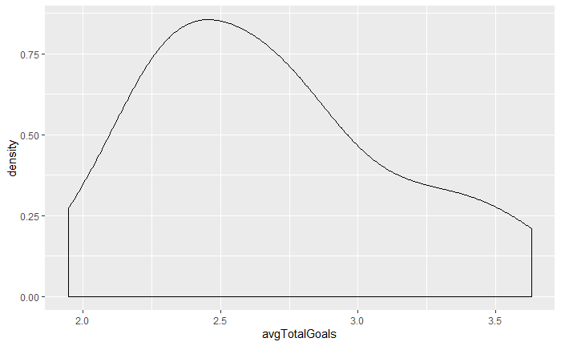

```r
ggplot(data=SerieAHome,aes(x=avgTotalGoals))+
  geom_density()
```

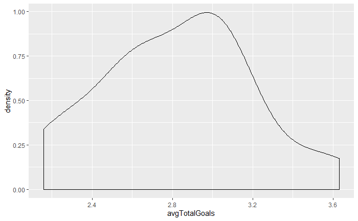

```r
ggplot(data=PremierLeagueHome,aes(x=avgTotalGoals))+
  geom_density()
```

- These two Density plots show that the most common total goals for SerieA games is about 2.45, and most ommon total goals for Premier League games is around 2.95, so initially it seems that Premier League matches have more goals.

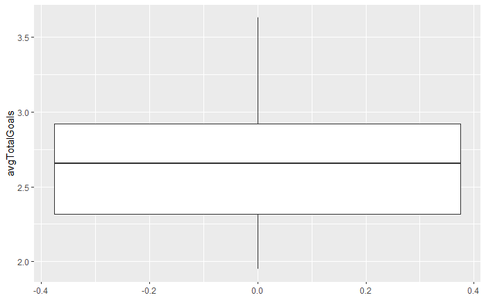

```r
ggplot(data=SerieAHome,aes(y=avgTotalGoals))+
  geom_boxplot()
```

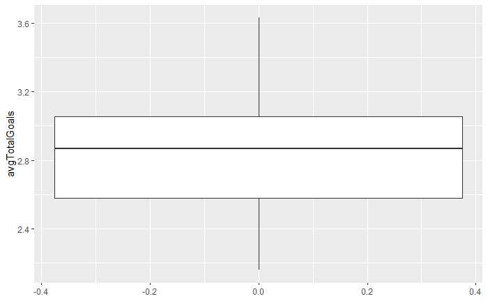

```r
ggplot(data=PremierLeagueHome,aes(y=avgTotalGoals))+
  geom_boxplot()
```

- this Boxplot shows that SerieA games have a wider range with lower minimums for goals scored than games in the Premier League and similar maximums

```r
combineddata <- rbind(SerieAHome, PremierLeagueHome)
```